# Tugas Pertemuan 2 - Penanganan Autokorelasi

Indra Mahib Z.R

## Library Used

```r
library(dplyr)
library(TTR)
library(forecast)
library(rio)
library(lmtest) #digunakan untuk uji formal pendeteksian autokorelasi
library(orcutt) #untuk membuat model regresi Cochrane-Orcutt
library(HoRM) #untuk membuat model regresi Hildreth-Lu
```

## Load Data

| Year | GDP |
| --- | --- |
| 1960 | 288884368 |
| 1961 | 322053713 |
| 1962 | 360698413 |
| 1963 | 383904762 |
| 1964 | 408349206 |
| 1965 | 443587302 |

untuk mempermudah perhitungan dan interpretasi, GDP akan dibagi 10^9 agar angka tidak terlalu besar.

## EDA

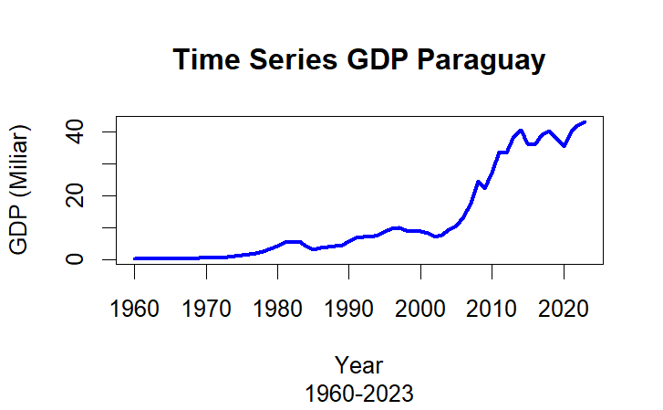

Terdapat kenaikan yang tinggi pada tahun 2000 awal. Untuk keperluan analisis dan tugas ini, kita akan mengambil sampai tahun 2000 saja.

### Subsetting 1960-2000

## Pemodelan Regresi Linear

```r
summary(model.reg)
```

```
Call:
lm(formula = GDP ~ Year, data = gdp.new)

Residuals:
     Min       1Q   Median       3Q      Max
-1.81064 -0.94585  0.00392  0.84203  1.88154

Coefficients:
              Estimate Std. Error t value Pr(>|t|)
(Intercept) -502.66344   27.75730  -18.11   <2e-16
Year           0.25580    0.01402   18.25   <2e-16

(Intercept) ***
Year        ***
---
Signif. codes:
0 ‘***’ 0.001 ‘**’ 0.01 ‘*’ 0.05 ‘.’ 0.1 ‘ ’ 1

Residual standard error: 1.062 on 39 degrees of freedom
Multiple R-squared:  0.8951,    Adjusted R-squared:  0.8925
F-statistic:   333 on 1 and 39 DF,  p-value: < 2.2e-16
```

Didapatkan hasil pemodelan dari regresi linear adalah

$$\begin{equation}
\hat{y} = -502.663 + 0.256 Year
\end{equation}$$

### Uji asumsi kenormalan sisaan

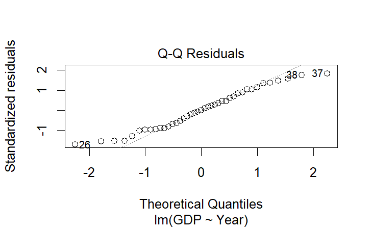

```r
resid.reg <- residuals(model.reg)
shapiro.test(resid.reg)
```

```
    Shapiro-Wilk normality test

data:  resid.reg
W = 0.96501, p-value = 0.2346
```

Asumsi normalitas sisaan terpenuhi

### Uji asumsi homoskedastisitas

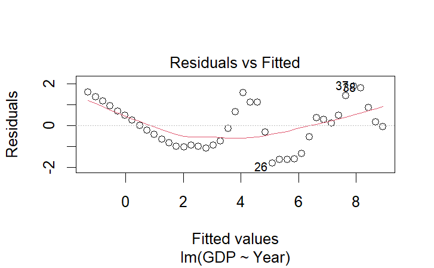

Seperti ada pola dalam Residual Vs Fitted.

```r
bptest(model.reg)
```

```
    studentized Breusch-Pagan test

data:  model.reg
BP = 0.94964, df = 1, p-value = 0.3298
```

Walaupun secara eksplorasi terlihat ragam tidak homogen karena berpola, namun uji formal menunjukan homosskedasitas ragam sisaan.

### Uji asumsi autokorelasi

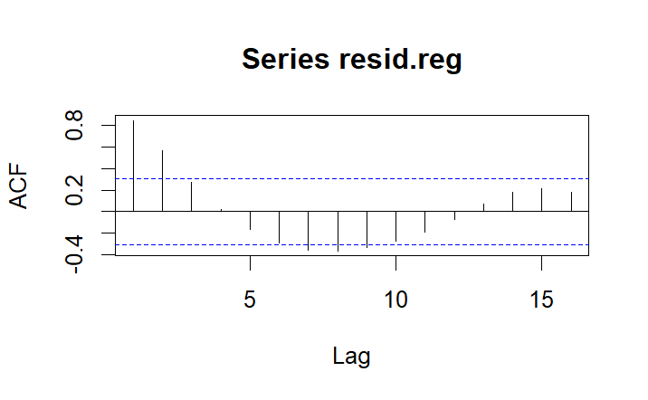

```r
acf(resid.reg)
```

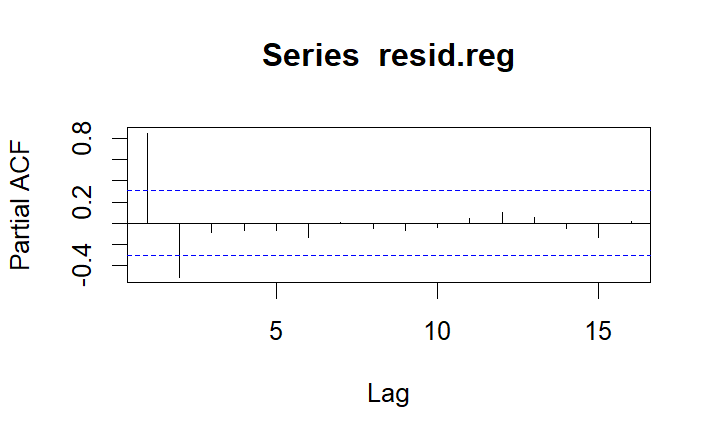

```r
pacf(resid.reg)
```

Plot ACF dan PACF menunjukan bahwa terdapat pengaruh lag 1 pada sisaan. Hal ini mengindikasikan adanya autokorelasi.

```r
dwtest(model.reg)
```

```
    Durbin-Watson test

data:  model.reg
DW = 0.25383, p-value = 6.492e-16
alternative hypothesis: true autocorrelation is greater than 0
```

Uji Durbin-Watson mendukung temuan kita sebelumnya. Terdapat autokorelasi pada model regresi linear. Autokorelasi yang terjadi cenderung autokorelasi positif. Karena itu kita lakukan penanganan autokorelasi.

## Penanganan Autokorelasi

### Cochrane-Orcutt

```r
summary(CO)
```

```
Call:
lm(formula = GDP ~ Year, data = gdp.new)

               Estimate  Std. Error t value
(Intercept) -577.854237   88.907941  -6.499
Year           0.293525    0.044768   6.557
             Pr(>|t|)
(Intercept) 1.179e-07 ***
Year        9.851e-08 ***
---
Signif. codes:
0 ‘***’ 0.001 ‘**’ 0.01 ‘*’ 0.05 ‘.’ 0.1 ‘ ’ 1

Residual standard error: 0.5091 on 38 degrees of freedom
Multiple R-squared:  0.5308 ,  Adjusted R-squared:  0.5184
F-statistic: 43 on 1 and 38 DF,  p-value: < 9.851e-08

Durbin-Watson statistic
(original):    0.25383 , p-value: 6.492e-16
(transformed): 0.95397 , p-value: 7.588e-05
```

Didapat persamaan regersi Cochrane-Orcutt adalah
$$\begin{equation}
\hat{y_{CO}} = -577.854 + 0.294 Year
\end{equation}$$
#### Uji autokorelasi

```r
dwtest(CO)
```

```
    Durbin-Watson test

data:  CO
DW = 0.95397, p-value = 7.588e-05
alternative hypothesis: true autocorrelation is greater than 0
```

Uji Durbin-Watson menunjukan bahwa autokorelasi belum juga teratasi

### Hildreth-Lu

Mencari nilai rho yang meminimumkan SSE

| rho | SSE |
| --- | --- |
| 0.1 | 34.2128 |
| 0.2 | 28.1053 |
| 0.3 | 22.8776 |
| 0.4 | 18.5296 |
| 0.5 | 15.0614 |
| 0.6 | 12.4729 |
| 0.7 | 10.7641 |
| 0.8 | 9.9351 |
| 0.9 | 9.9858 |

nilai SSE terkecil didapat pada antara 0.8-0.9

```r
## Optimum
tabOpt[tabOpt$SSE==min(tabOpt$SSE),"rho"]
```

```
[1] 0.844
```

Nilai rho optimum yang di dapat adalah 0.844

```r
#transform balik
cat("y = ", coef(HidL)[1]/(1-0.844), "+", coef(HidL)[2],"x", sep = "")
```

```
y = -577.7413+0.2934686x
```

Persamaan yang terbentuk dari pemodelan hidret-lu adalah

$$\begin{equation}
\hat{y_{HL}} = -577.741 + 0.293 Year
\end{equation}$$

#### Uji autokorelasi

```r
dwtest(HidL)
```

```
    Durbin-Watson test

data:  HidL
DW = 0.95379, p-value = 7.566e-05
alternative hypothesis: true autocorrelation is greater than 0
```

Autokorelasi juga masih ada.

## Kesimpulan

Dari hasil analisis, kita menemukan bahwa autokorelasi masih ada pada model regresi linear. Penanganan autokorelasi dengan metode Cochrane-Orcutt dan Hildreth-Lu juga belum mampu menghilangkan autokorelasi. Diperlukan metode lain untuk mengatasi autokorelasi pada model regresi linear ini.